title: “UBDC CCTV data” author: “Nick Bailey” date: “26/04/2021” output: html_document —

# UBDC CCTV pedestrian counts

## Nick Bailey - 27/04/2021

```r
knitr::opts_chunk$set(echo = TRUE)

# load packages
pacman::p_load(httr, jsonlite, RCurl, vroom, lubridate, here, hms, tidyverse)
```

# Reading the data

## Data from API

Read data from UBDC API for March-May 2021.

Note that this removes duplicated rows which occurred on at least one day in this period.

```r
# Set parameters for getting data from the API
first_date <- "2021-03-01"
last_date <- "2021-05-31"

# # url for all dates
# api_url <- "https://api.ubdc.ac.uk/cctv/counts/"

# url with date filters
api_url <- paste("https://api.ubdc.ac.uk/cctv/counts",
                 # location,
                 first_date,
                 last_date,
                 sep="/")

# get data from api - class 'response'
cctv <- GET(url = api_url)

# get content - class 'character'
# - replacing the parts that make it uniquely HTML
cctv_content <- content(cctv, "text") %>%
  gsub("<html><body><p>","",.) %>%
  gsub("</p></body></html>","",.) %>%
  gsub("&quot;",'\"',.)

# this converts to df with two cols - '.' separator in 'name'
df_cctv <- enframe(unlist(fromJSON(cctv_content)))

# # variable 'name' only ever has one '.' in it
# df_cctv %>%
#   mutate(temp = str_count(name, "\\.")) %>%
#   group_by(temp) %>%
#   summarise(N = n())

# split name into caseid and variable
df_cctv <- df_cctv %>%
  separate(col = name, sep = "\\.", into = c("caseid", "variable"))

# pivot wider, reformat, make date
df_cctv <- df_cctv %>%
  pivot_wider(caseid, names_from = "variable") %>%
  select(-caseid) %>%
  mutate(timestp_UTC = as_datetime(timestp_UTC)) %>%
  mutate_at(vars(car:truck),
            list(as.numeric)) %>%
  mutate(date = date(timestp_UTC),
         location_type = factor(case_when(grepl("Argyle_St", location) ~ 1,
                                          grepl("Gallowgate", location) ~ 1,
                                          grepl("George_Sq", location) ~ 1,
                                          grepl("High_St", location) ~ 1,
                                          grepl("Hope_St", location) ~ 1,
                                          grepl("Killermont_St", location) ~ 1,
                                          grepl("Sauchiehall_St", location) ~ 1,
                                          grepl("Byres_Rd", location) ~ 2,
                                          grepl("Duke_St", location) ~ 2,
                                          grepl("Maryhill_Rd", location) ~ 2,
                                          grepl("Victoria_Rd", location) ~ 2,
                                          grepl("Park", location) ~ 3,
                                          grepl("Glasgow_Green", location) ~ 3,
                                          grepl("Broomielaw", location) ~ 4,
                                          grepl("Clyde_Walkway", location) ~ 4,
                                          grepl("Clyde_walkway", location) ~ 4,
                                          grepl("Finnieston_Bridge", location) ~ 4,
                                          grepl("Forth_Clyde_Canal", location) ~ 4,
                                          TRUE ~ 9),
                                levels = c(1,2,3,4,9),
                                labels = c("City centre", "Other centre",
                                           "Parks", "River/canal", "Other"))) %>%
  distinct()


# # check location classifcation
# table(df_cctv$location, df_cctv$location_type)
```

## Data from zip file

Alternative way to import data is by manually downloading the zip file from the UBDC website to the ‘data’ folder. Code identifies the most recent .zip file in the ‘data’ folder, then reads the structure and csv file name(s), and reads in data from csv files.

[Commented out.]

```r
# # zip file - name of most recent .zip in 'data' directory
# # - doesn't work in one go for some reason
# zip_file <- data.frame(names = list.files(here("data")))
# zip_file <- zip_file %>%
#   cbind(file.info(here("data", zip_file$names))) %>%
#   filter(grepl("zip", names)) %>%
#   filter(mtime == max(mtime)) %>%
#   pull(names)
#
# # zip file structure
# zip_file_structure <- unzip(here("data", zip_file), list = TRUE)
#
# # csv file name
# # - if more than one, a list
# csv_file <- zip_file_structure %>%
#   filter(grepl("csv", Name)) %>%
#   pull(Name)
#
# # read all 'measures' csv files
# df_cctv <- vroom(map(csv_file, ~ unz(here("data", zip_file), .x)))  %>%
#   mutate(date = date(timestp_UTC),
#          location_type = factor(case_when(grepl("Argyle_St", location) ~ 1,
#                                           grepl("Gallowgate", location) ~ 1,
#                                           grepl("George_Sq", location) ~ 1,
#                                           grepl("High_St", location) ~ 1,
#                                           grepl("Hope_St", location) ~ 1,
#                                           grepl("Killermont_St", location) ~ 1,
#                                           grepl("Sauchiehall_St", location) ~ 1,
#                                           grepl("Byres_Rd", location) ~ 2,
#                                           grepl("Duke_St", location) ~ 2,
#                                           grepl("Maryhill_Rd", location) ~ 2,
#                                           grepl("Victoria_Rd", location) ~ 2,
#                                           grepl("Park", location) ~ 3,
#                                           grepl("Glasgow_Green", location) ~ 3,
#                                           grepl("Broomielaw", location) ~ 4,
#                                           grepl("Clyde_Walkway", location) ~ 4,
#                                           grepl("Clyde_walkway", location) ~ 4,
#                                           grepl("Finnieston_Bridge", location) ~ 4,
#                                           grepl("Forth_Clyde_Canal", location) ~ 4,
#                                           TRUE ~ 9),
#                                 levels = c(1,2,3,4,9),
#                                 labels = c("City centre", "Other centre",
#                                            "Parks", "River/canal", "Other"))) %>%
#   filter(date >= date(first_date) & date <= date(last_date)) %>%
#   distinct()
#
# # str(df_cctv)
```

Latest date/time

```r
max(df_cctv$timestp_UTC)
```

```
## [1] "2021-04-26 22:37:32 UTC"
```

```r
sun <- df_cctv %>%
  select(date) %>%
  filter(wday(date) == 1) %>%
  group_by(date) %>%
  summarise() %>%
  pull(date)
sat <- df_cctv %>%
  select(date) %>%
  filter(wday(date) == 7) %>%
  group_by(date) %>%
  summarise() %>%
  pull(date)
```

## Locations - counts per day

Last month - number of counts by location: two counts per hour, 10 hours - max should be 20 counts.

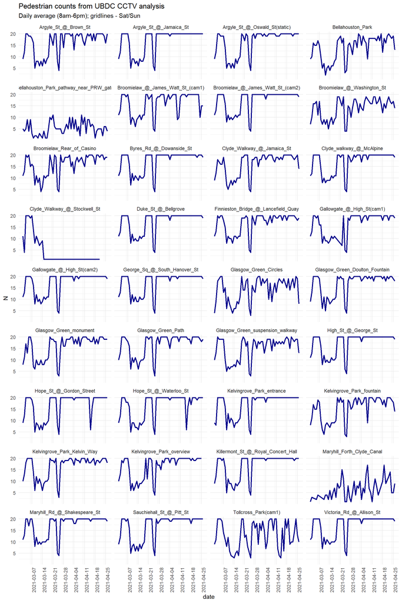

```r
df_cctv %>%
  # filter(date >= (Sys.Date() - 31)) %>%
  filter(hour(timestp_UTC) >= 8 & hour(timestp_UTC) < 18) %>%
  group_by(location, date) %>%
  summarise(N = n()) %>%
  ggplot(aes(x = date, y = N)) +
  geom_line(size = 1, colour = "darkblue") +
  facet_wrap(~ location, ncol = 4) +
  scale_x_date(breaks = sun,
               minor_breaks = sat) +
  labs(title = "Pedestrian counts from UBDC CCTV analysis",
       subtitle = "Daily average (8am-6pm); gridlines - Sat/Sun") +
  theme_minimal() +
  theme(axis.text.x = element_text(angle = 90))
```

List dropped locations.

```r
counts_per_day_min <- 15
valid_days_min <- 30

location_keep <- df_cctv %>%
  filter(date >= (Sys.Date() - 31)) %>%
  filter(hour(timestp_UTC) >= 8 & hour(timestp_UTC) < 18) %>%
  group_by(location, date) %>%
  summarise(counts_per_day = n()) %>%
  mutate(valid = (counts_per_day >= counts_per_day_min)) %>%
  group_by(location) %>%
  summarise(valid_days = sum(valid)) %>%
  filter(valid_days >= valid_days_min) %>%
  pull(location)
location_drop <- df_cctv %>%
  filter(date >= (Sys.Date() - 31)) %>%
  filter(hour(timestp_UTC) >= 8 & hour(timestp_UTC) < 18) %>%
  group_by(location, date) %>%
  summarise(counts_per_day = n()) %>%
  mutate(valid = (counts_per_day >= counts_per_day_min)) %>%
  group_by(location) %>%
  summarise(valid_days = sum(valid)) %>%
  filter(valid_days < valid_days_min) %>%
  pull(location)
location_drop
```

```
##  [1] "Argyle_St_@_Brown_St"
##  [2] "Bellahouston_Park"
##  [3] "Bellahouston_Park_pathway_near_PRW_gate"
##  [4] "Broomielaw_@_James_Watt_St_(cam1)"
##  [5] "Broomielaw_@_Washington_St"
##  [6] "Clyde_Walkway_@_Stockwell_St"
##  [7] "Glasgow_Green_Circles"
##  [8] "Glasgow_Green_suspension_walkway"
##  [9] "Kelvingrove_Park_fountain"
## [10] "Maryhill_Forth_Clyde_Canal"
## [11] "Tollcross_Park(cam1)"
```

## Pedestrian counts

Average daily counts by week day, comparing days since the re-opening of shops etc. to the preceding weeks.

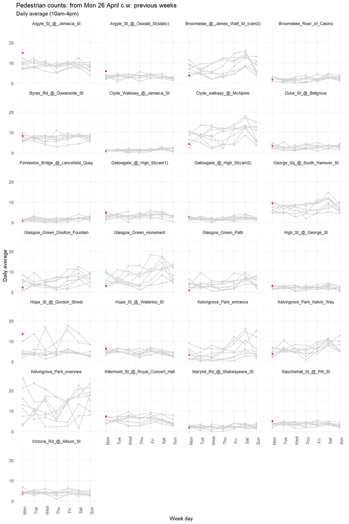

```r
df_cctv %>%
  filter(date >= date("2021-03-01")) %>%
  filter(hour(timestp_UTC) >= 10 & hour(timestp_UTC) < 16) %>%
  filter(location %in% location_keep) %>%
  group_by(location, date) %>%
  summarise(person = mean(person),
            N = n()) %>%
  mutate(wday = factor(wday(date, week_start = 1),
                       labels = c("Mon", "Tue", "Wed", "Thu", "Fri", "Sat", "Sun")),
         week = isoweek(date),
         after_opening = (date >= date("2021-04-26"))) %>%
  ggplot(aes(x = wday, y = person, group = week)) +
  geom_point(aes(colour = after_opening)) +
  geom_line(aes(colour = after_opening), size = 0.6) +
  scale_colour_manual(values = c("lightgrey", "red")) +
  facet_wrap(~ location, ncol = 4) +
  labs(title = "Pedestrian counts: from Mon 26 April c.w. previous weeks",
       subtitle = "Daily average (10am-4pm)",
       x = "Week day",
       y = "Daily average") +
  theme_minimal() +
  theme(legend.position = "none") +
  theme(axis.text.x = element_text(angle = 90))
```

City centre

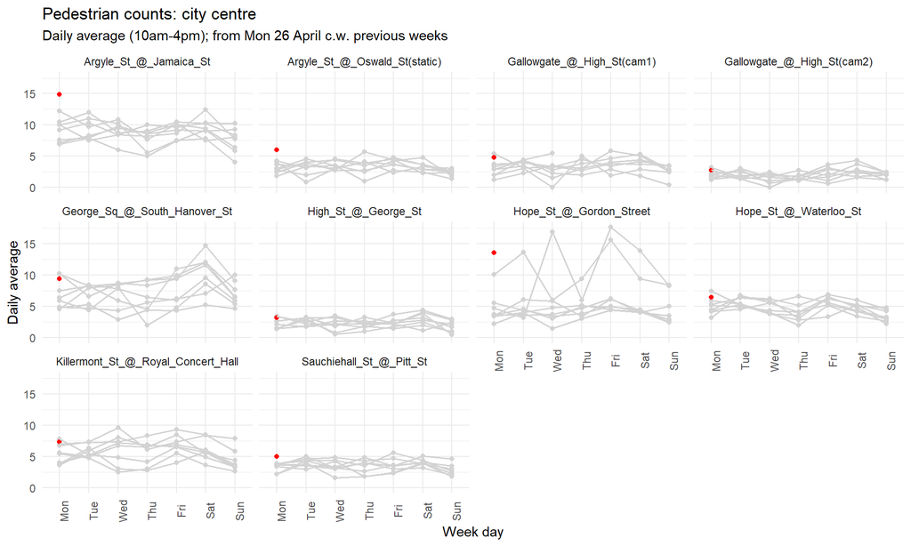

```r
df_cctv %>%
  filter(date >= date("2021-03-01")) %>%
  filter(hour(timestp_UTC) >= 10 & hour(timestp_UTC) < 16) %>%
  filter(location %in% location_keep) %>%
  filter(location_type == "City centre") %>%
  group_by(location, date) %>%
  summarise(person = mean(person),
            N = n()) %>%
  mutate(wday = factor(wday(date, week_start = 1),
                       labels = c("Mon", "Tue", "Wed", "Thu", "Fri", "Sat", "Sun")),
         week = isoweek(date),
         after_opening = (date >= date("2021-04-26"))) %>%
  ggplot(aes(x = wday, y = person, group = week)) +
  geom_point(aes(colour = after_opening)) +
  geom_line(aes(colour = after_opening), size = 0.6) +
  scale_colour_manual(values = c("lightgrey", "red")) +
  facet_wrap(~ location, ncol = 4) +
  labs(title = "Pedestrian counts: city centre",
       subtitle = "Daily average (10am-4pm); from Mon 26 April c.w. previous weeks",
       x = "Week day",
       y = "Daily average") +
  theme_minimal() +
  theme(legend.position = "none") +
  theme(axis.text.x = element_text(angle = 90))
```

Other centres

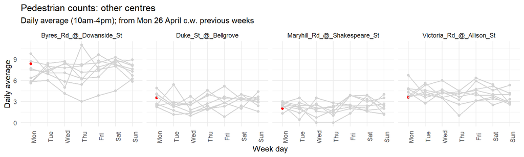

```r
df_cctv %>%
  filter(date >= date("2021-03-01")) %>%
  filter(hour(timestp_UTC) >= 10 & hour(timestp_UTC) < 16) %>%
  filter(location %in% location_keep) %>%
  filter(location_type == "Other centre") %>%
  group_by(location, date) %>%
  summarise(person = mean(person),
            N = n()) %>%
  mutate(wday = factor(wday(date, week_start = 1),
                       labels = c("Mon", "Tue", "Wed", "Thu", "Fri", "Sat", "Sun")),
         week = isoweek(date),
         after_opening = (date >= date("2021-04-26"))) %>%
  ggplot(aes(x = wday, y = person, group = week)) +
  geom_point(aes(colour = after_opening)) +
  geom_line(aes(colour = after_opening), size = 0.6) +
  scale_colour_manual(values = c("lightgrey", "red")) +
  facet_wrap(~ location, ncol = 4) +
  labs(title = "Pedestrian counts: other centres",
       subtitle = "Daily average (10am-4pm); from Mon 26 April c.w. previous weeks",
       x = "Week day",
       y = "Daily average") +
  theme_minimal() +
  theme(legend.position = "none") +
  theme(axis.text.x = element_text(angle = 90))
```

Parks

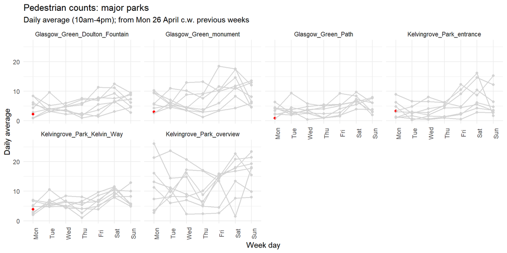

```r
df_cctv %>%
  filter(date >= date("2021-03-01")) %>%
  filter(hour(timestp_UTC) >= 10 & hour(timestp_UTC) < 16) %>%
  filter(location %in% location_keep) %>%
  filter(location_type == "Parks") %>%
  group_by(location, date) %>%
  summarise(person = mean(person),
            N = n()) %>%
  mutate(wday = factor(wday(date, week_start = 1),
                       labels = c("Mon", "Tue", "Wed", "Thu", "Fri", "Sat", "Sun")),
         week = isoweek(date),
         after_opening = (date >= date("2021-04-26"))) %>%
  ggplot(aes(x = wday, y = person, group = week)) +
  geom_point(aes(colour = after_opening)) +
  geom_line(aes(colour = after_opening), size = 0.6) +
  scale_colour_manual(values = c("lightgrey", "red")) +
  facet_wrap(~ location, ncol = 4) +
  labs(title = "Pedestrian counts: major parks",
       subtitle = "Daily average (10am-4pm); from Mon 26 April c.w. previous weeks",
       x = "Week day",
       y = "Daily average") +
  theme_minimal() +
  theme(legend.position = "none") +
  theme(axis.text.x = element_text(angle = 90))
```

River/canal

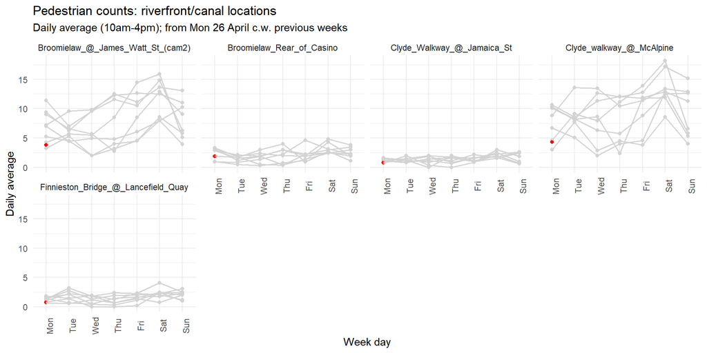

```r
df_cctv %>%
  filter(date >= date("2021-03-01")) %>%
  filter(hour(timestp_UTC) >= 10 & hour(timestp_UTC) < 16) %>%
  filter(location %in% location_keep) %>%
  filter(location_type == "River/canal") %>%
  group_by(location, date) %>%
  summarise(person = mean(person),
            N = n()) %>%
  mutate(wday = factor(wday(date, week_start = 1),
                       labels = c("Mon", "Tue", "Wed", "Thu", "Fri", "Sat", "Sun")),
         week = isoweek(date),
         after_opening = (date >= date("2021-04-26"))) %>%
  ggplot(aes(x = wday, y = person, group = week)) +
  geom_point(aes(colour = after_opening)) +
  geom_line(aes(colour = after_opening), size = 0.6) +
  scale_colour_manual(values = c("lightgrey", "red")) +
  facet_wrap(~ location, ncol = 4) +
  labs(title = "Pedestrian counts: riverfront/canal locations",
       subtitle = "Daily average (10am-4pm); from Mon 26 April c.w. previous weeks",
       x = "Week day",
       y = "Daily average") +
  theme_minimal() +
  theme(legend.position = "none") +
  theme(axis.text.x = element_text(angle = 90))
```